# Part II - Ford GoBike System Dataset

## by Carla Mota Leal

## Investigation Overview

**Objective:** In this investigation, I wanted to look at the variables presented in the dataset of the Ford GoBike system and evaluate what could be assumed for users behavior, gender distribution, age demographics, and usage patterns, which can be valuable for strategic planning, marketing campaigns, and service improvements.

## Dataset Overview

This data set includes information about individual rides made in a bike-sharing system covering the greater San Francisco Bay area, California. The dataset started with 183412 rows and 16 columns, with the variables:

- *duration_sec, start_time, end_time, start_station_id, start_station_name, start_station_latitude, start_station_longitude, end_station_id, end_station_name, end_station_latitude, end_station_longitude, bike_id, user_type, member_birth_year, member_gender, and bike_share_for_all_trip.*

## Users behavior

After wrangling the original dataset, the dataframe went from 183412 to 174880 rows. While visualizing the type of customers distribution in the bike service:

- The majority of bike service customers are **subscribed members**, highlighting the importance of subscriber loyalty and the benefits of subscription-based models.
- Subscribers account for a significant portion of users during high-volume hours, busy weekdays, and throughout the week.

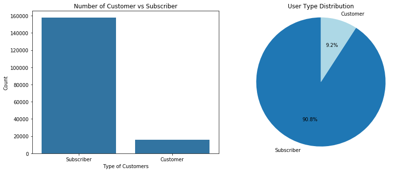

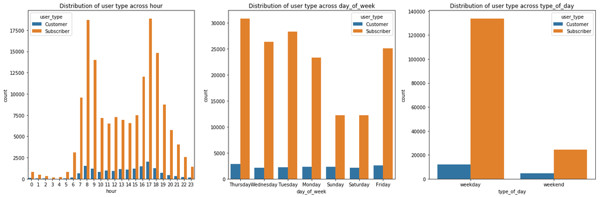

## Usage patterns

After creating new columns for weekday or weekend, duration in minutes,and hour & day, here the considerations of the investigation of the usage patterns:

- Weekdays, especially Thursday, Tuesday, and Wednesday, witness a higher frequency of bike trips.
- The majority of bike trips have a duration ranging from 3 to 20 minutes.
- The station located at Market St at 10th St. serves as the most popular starting point for bike trips.
- Peak usage hours for the bike service align with typical morning and evening commuting times, specifically around 8 AM and 5 PM.

**In summary, the analysis of usage patterns indicates that the bike service is primarily utilized for weekday commuting, short-distance travel, and during peak commuting hours. The subscription model plays a significant role in driving usage, particularly during high-demand periods.**

```
Text(0.5,1,'Number of trips per type of day')
```

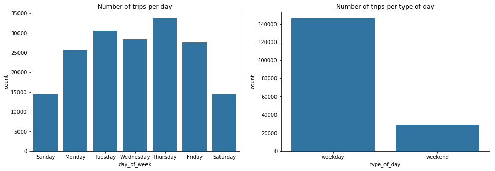

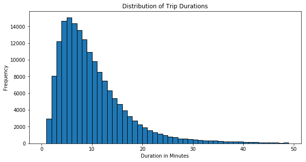

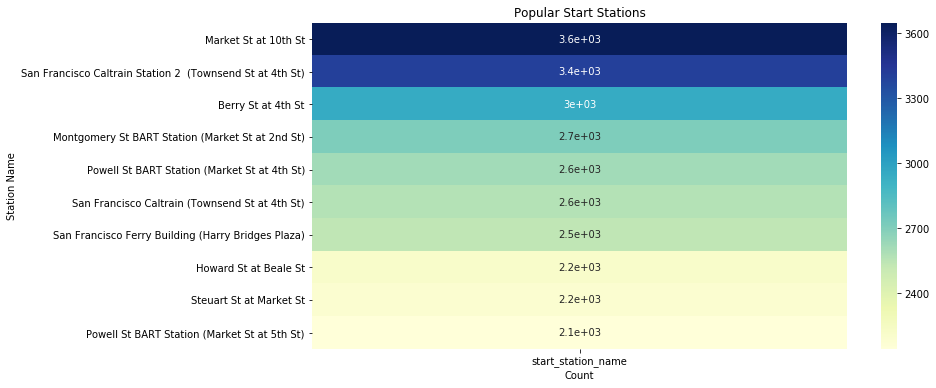

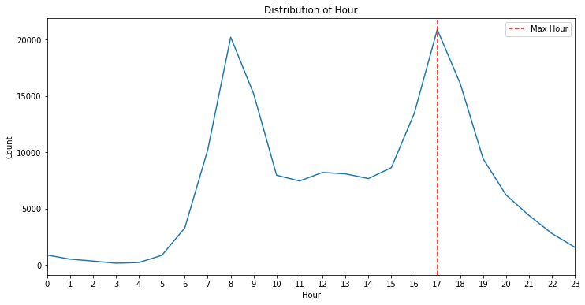

## Age demographic and gender distribution

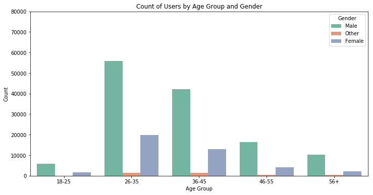

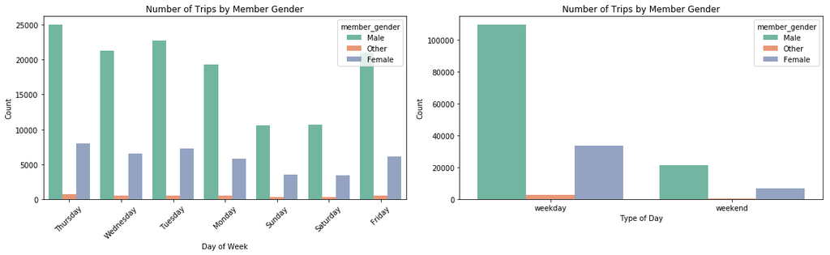

### Conclusion

*These observations can help inform marketing strategies, service improvements, and target audience considerations for the bike service.*